# The Chicago School and Subcultural Theories

CRIM 104

## Brazil’s favelas

[video not shown]

## Today’s theories

- Social disorganization theory
- Cultural transmission theory
- Differential association theory
- Subculture of delinquency theory
- Differential opportunity theory

# The Chicago School

## The Chicago School’s context

- Various social changes led to:
  - Rapid urbanization
  - Increased visibility of poverty
- Intellectual interests:
  - Scrutiny of urban poor’s condition
  - Emphasis on social “science” and scientific studies
  - Sociological interpretation/application of biological concepts
    - Often referred to as the Ecological School

## Burgess’s Concentric Zone Theory

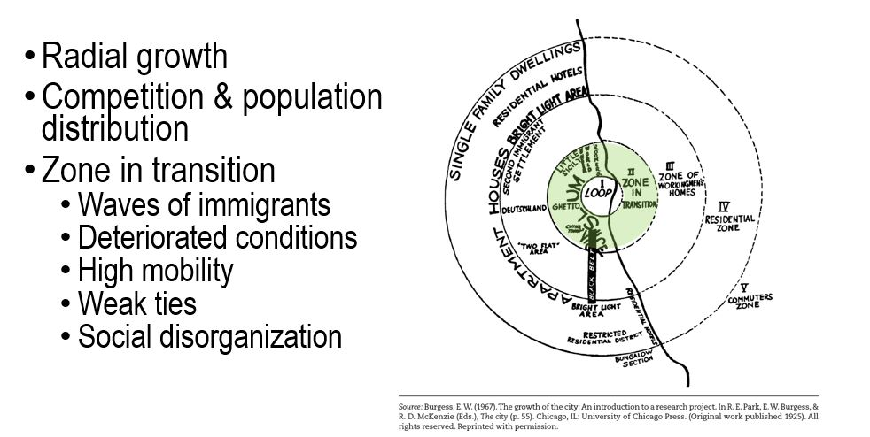

## Shaw and McKay’s Social Disorganization Theory

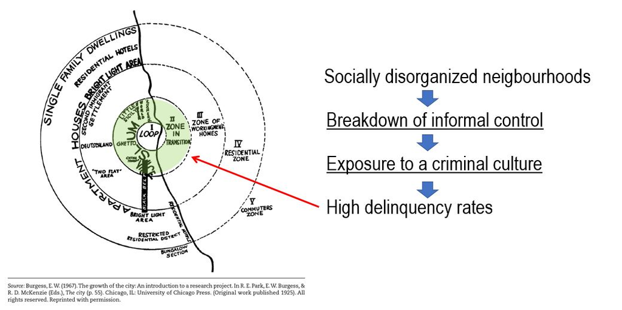

## Informal social control

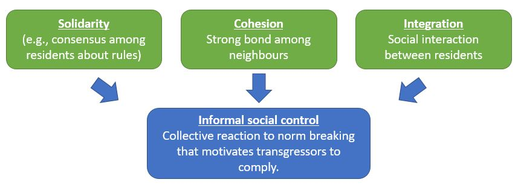

## Heavy metal ruled

[figure not shown]

## This is more accurate

[figure not shown]

## Just hanging out

[figure not shown]

## Shaw & McKay’s Cultural Transmission Theory

- Juveniles in socially-disorganized areas have greater exposure to & opportunity for delinquency & crime
- Existing delinquent/criminal values in area are transmitted to the youth

## Symbolic Interactionism

- Our behaviour is shaped by the meaning we assign to things
- Meanings are derived from our interactions with others
- Our self identity are determined by our interactions with others
- Identities are situation-specific

## Selling’s Conflict Theory

- Behaviours are confined by rules of conduct learned in childhood
- Rules may vary among cultures
- Dominant group in society may turn its rules into laws
- Types of conflict with these rules
  - Primary conflict: two different cultures govern behaviour (immigrants)
  - Secondary conflict: subcultures with different values that develop in certain areas

# Differential Association Theory

## Your friend is bad influence!

[figure not shown]

## Edwin Sutherland

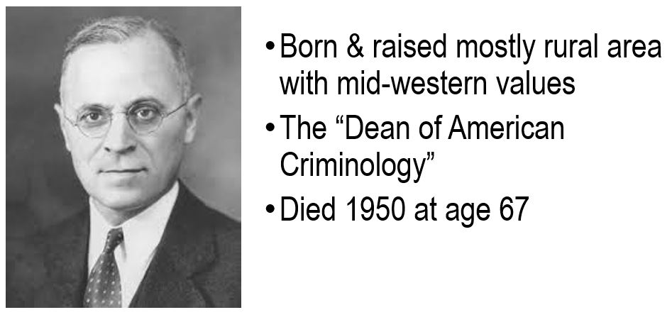

## Sutherland’s Differential Association

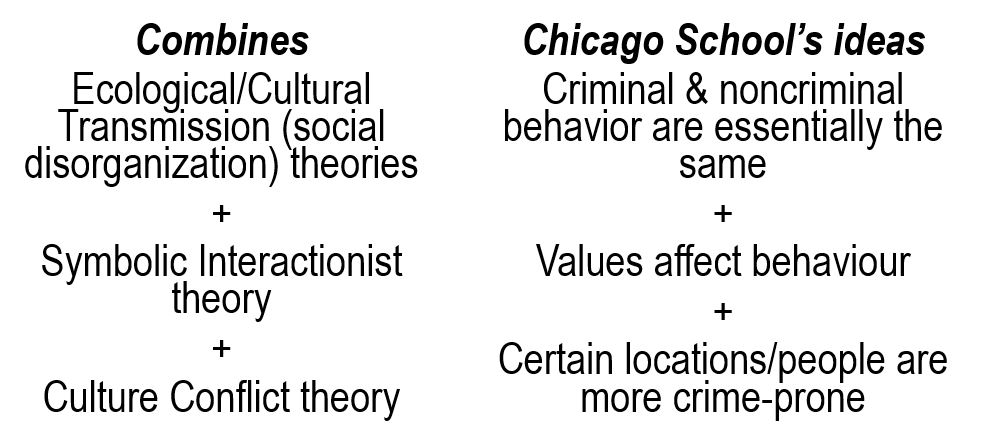

## Differential Association Theory: Main Points

- Criminal behaviour is learned (just as any other behavior)
- Learning takes places in social settings
- The largest part of learning takes place with those who are most important to us
- The intimate social environment provides setting for learning two things:
  - How to accomplish behaviour
  - How view that behaviour

## Differential Association Theory: Main Points

- Values about certain behaviour may conflict with laws
- As we receive many statements about values, the weight of those statements (importance and closeness of those who convey them) is more important than actual number of statements
- Criminal behaviour takes place when weight of the values concerning a particular behaviour is in opposition to the legal codes

## “Goodfellas”

[video not shown]

# Subculture Theories

## How does this set of rules and views develop?

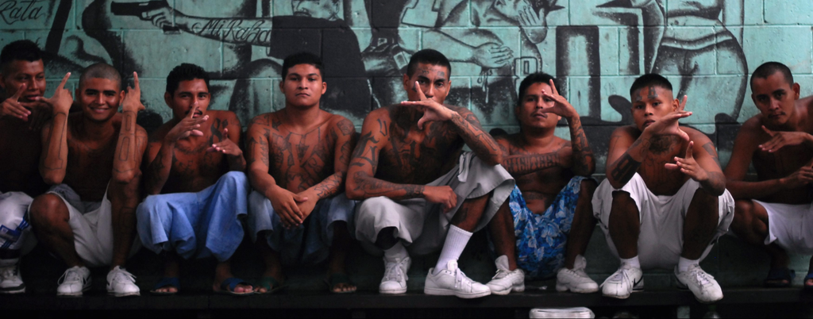

## Subcultural Theories

- Proposed 1950s-1960s
- These theories focus on:
  - Gang delinquency theories (except Subculture of violence theory)
  - The lower-class
  - Urban areas
  - Minorities

## Today’s theories

- Cohen’s Subculture of Delinquecy
- Cloward & Ohlin’s Differential Opportunity Theory

## Cohen’s Subculture of Delinquency

- Society members share a common value system
- Value system presents cultural goals, most of which build status
- Social institutions (schools) use those values in evaluating students

## Lower-class kids

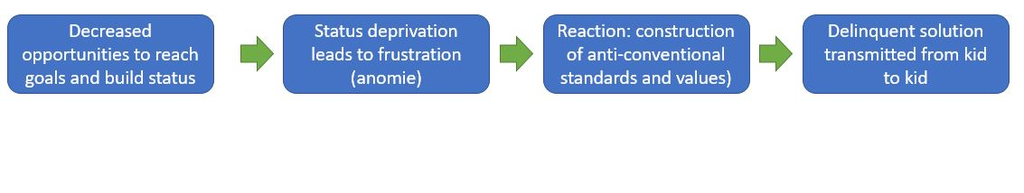

## Cloward & Ohlin’s Differential Opportunity Theory

- Different types of gang subcultures
- Your location determines access to gang subculture

## Gang Subcultures

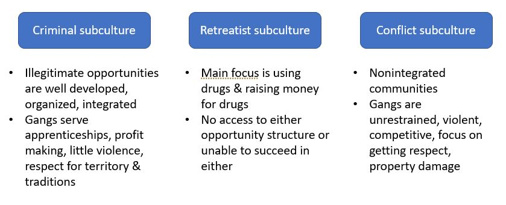

# Important content

## Key concepts and terms

- Social disorganization
- Informal social control
- Symbolic interactionism
- Primary & secondary culture conflict
- Retreatist subculture
- Criminal subculture
- Conflict subcutlure